# AN588_Zombies_benap_homeworkcode

Ben Peters

2025-03-02

```r
survivor_data <- read.csv("zombies.csv", header = T)
head(survivor_data)
```

```
##   id first_name last_name gender   height   weight zombies_killed
## 1  1      Sarah    Little Female 62.88951 132.0872              2
## 2  2       Mark    Duncan   Male 67.80277 146.3753              5
## 3  3    Brandon     Perez   Male 72.12908 152.9370              1
## 4  4      Roger   Coleman   Male 66.78484 129.7418              5
## 5  5      Tammy    Powell Female 64.71832 132.4265              4
## 6  6    Anthony     Green   Male 71.24326 152.5246              1
##   years_of_education                           major      age
## 1                  1                medicine/nursing 17.64275
## 2                  3 criminal justice administration 22.58951
## 3                  1                       education 21.91276
## 4                  6                  energy studies 18.19058
## 5                  3                       logistics 21.10399
## 6                  4                  energy studies 21.48355
```

### 1.

**Calculate the population mean and standard deviation for each quantitative random variable (height, weight, age, number of zombies killed, and years of education). NOTE: You will not want to use the built in var() and sd() commands as these are for samples.**

```r
popsd <- function(x){ #the default sd function returns the sample standard deviation, so let's make a function that calculates the population parameter by multiplying by the square root of n/n-1 of the population
  sqrt(length(x)/(length(x) - 1))*sd(x)
}
```

```r
# Height
mean(survivor_data$height)
```

```
## [1] 67.6301
```

```r
popsd(survivor_data$height)
```

```
## [1] 4.312282
```

```r
# Weight
mean(survivor_data$weight)
```

```
## [1] 143.9075
```

```r
popsd(survivor_data$weight)
```

```
## [1] 18.41027
```

```r
# Age
mean(survivor_data$age)
```

```
## [1] 20.04696
```

```r
popsd(survivor_data$age)
```

```
## [1] 2.966549
```

```r
# Kills
mean(survivor_data$zombies_killed) # kinda pathetic numbers tbh
```

```
## [1] 2.992
```

```r
popsd(survivor_data$zombies_killed)
```

```
## [1] 1.749301
```

```r
# Years of Education
mean(survivor_data$years_of_education)
```

```
## [1] 2.996
```

```r
popsd(survivor_data$years_of_education)
```

```
## [1] 1.677381
```

### 2.

**Use {ggplot} to make boxplots of each of these variables by gender.**

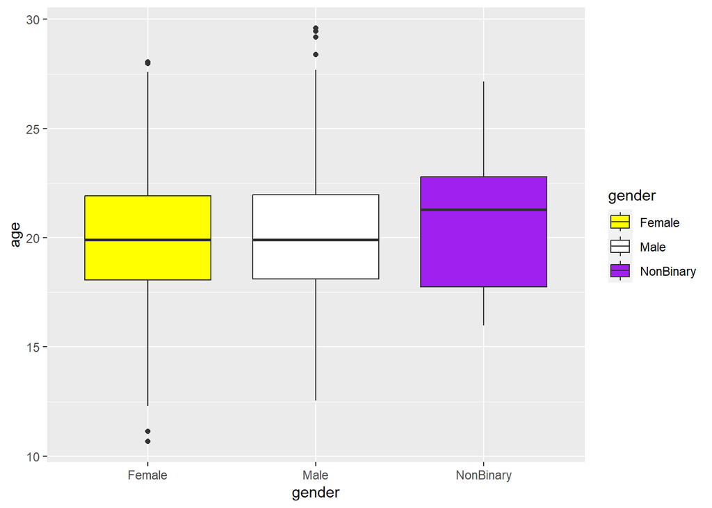

```r
library(ggplot2)
library(tidyr)
library(dplyr)
boxplots <- ggplot(survivor_data, aes(x = gender, fill = gender)) +
  scale_fill_manual(values = c("yellow","white","purple","black")) #this just manually defines the colors the fill parameter is going to use

boxplots +
  geom_boxplot(aes(y = age))
```

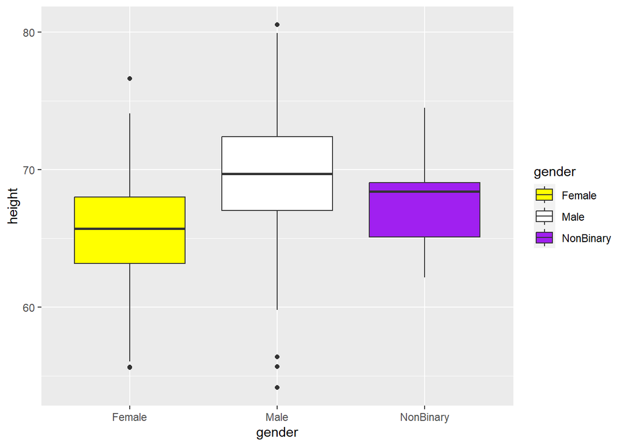

```r
boxplots +
  geom_boxplot(aes(y = height))
```

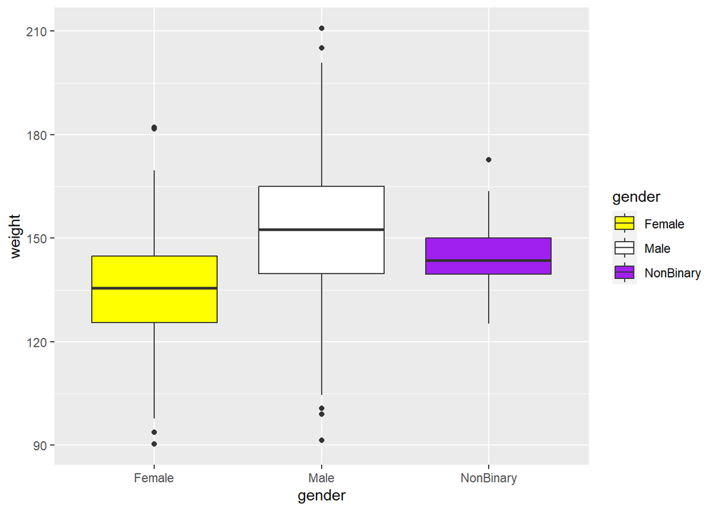

```r
boxplots +
  geom_boxplot(aes(y = weight))
```

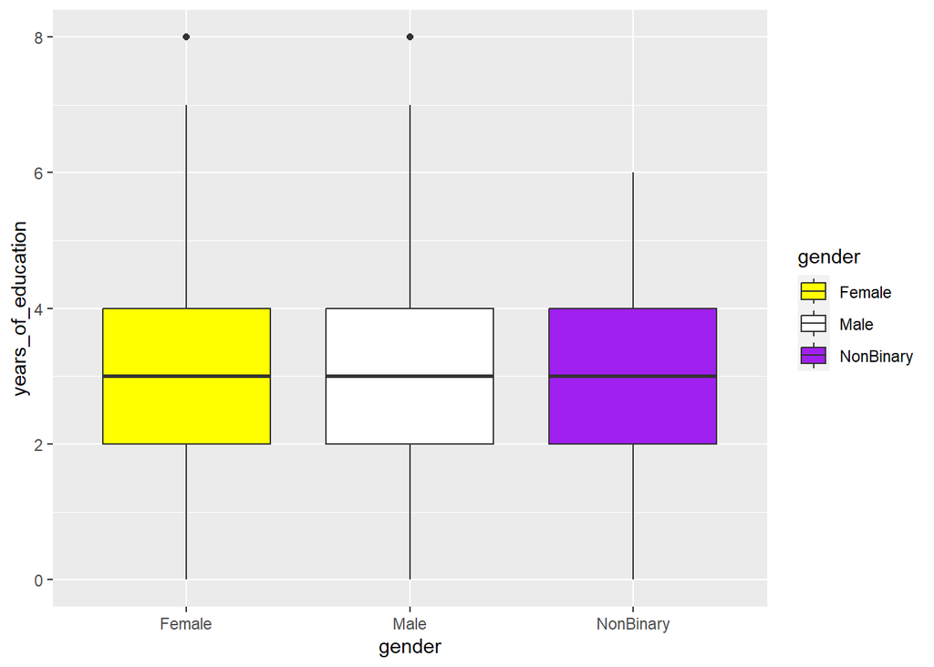

```r
boxplots +
  geom_boxplot(aes(y = years_of_education))
```

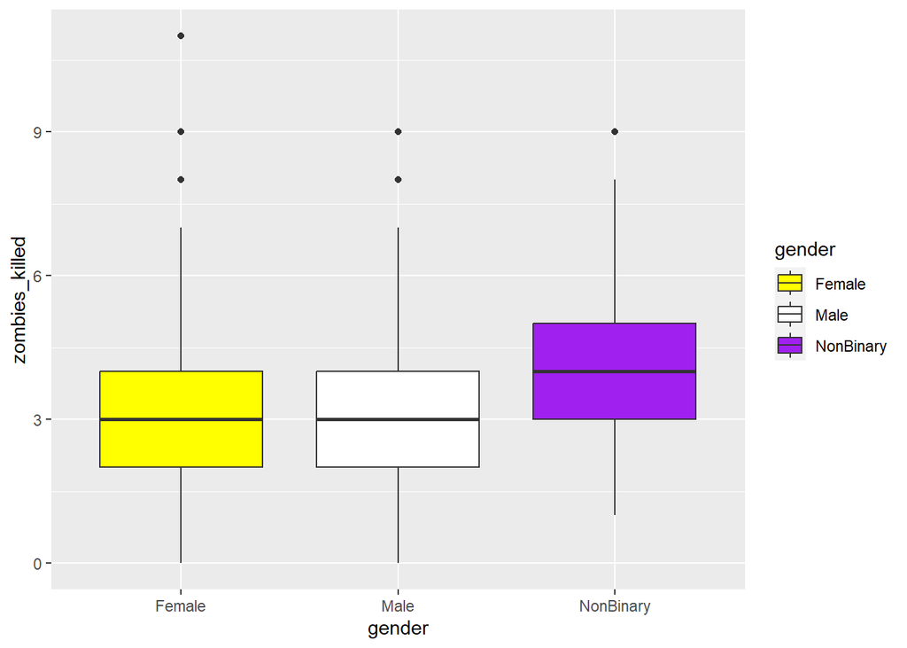

```r
boxplots +
  geom_boxplot(aes(y = zombies_killed)) #give the enbies a gun
```

### 3.

**Use {ggplot} to make scatterplots of height and weight in relation to age. Do these variables seem to be related? In what way?**

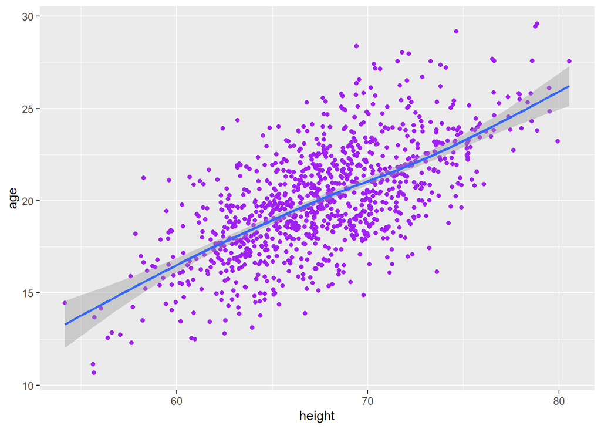

```r
ggplot(data = survivor_data, aes(x = height, y = age)) +
  geom_point(color = "purple") +
  geom_smooth()
```

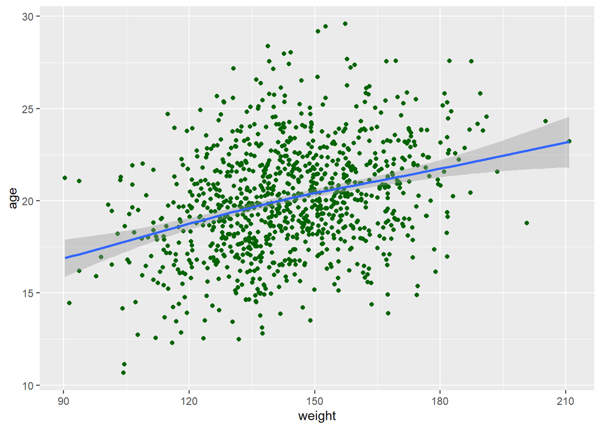

```r
ggplot(data = survivor_data, aes(x = weight, y = age)) +
  geom_point(color = "darkgreen") +
  geom_smooth()
```

```r
# I was curious so I decided to calculate pearson R for both comparisons
cor(survivor_data$height, survivor_data$age, method = "pearson")
```

```
## [1] 0.6483801
```

```r
cor(survivor_data$weight, survivor_data$age, method = "pearson")
```

```
## [1] 0.3203203
```

### 4.

**Using histograms and Q-Q plots, check whether the quantitative variables seem to be drawn from a normal distribution. Which seem to be and which do not (hint: not all are drawn from the normal distribution)? For those that are not normal, can you determine from which common distribution they are drawn?**